# Time Series Analysis of Spotify Data

Author

Frankie, Anna, Piper, Kate, Ayaan

## Introduction

Companies are always looking for methods to analyze the popularity of their products, as well as what predicts that popularity over time. The music industry is no different: Spotify has developed a popularity index that ranks songs from 0 to 100 on how popular they are compared to other songs. The score has three components: total streams of a song, how recently a song has been played, and the frequency at which a song is played. This score is immensely useful to Spotify and to music industry professionals on a song-by-song basis, because having a high popularity score increases a song’s discoverability to listeners. However, modeling mean values of song popularity over time also has the potential to be useful for Spotify (or similar streaming platforms), because it could help companies understand the factors that play into users’ satisfaction with the platform and listening patterns over time, as well as predict future values of popularity that might inform business decisions. We have obtained a Kaggle dataset containing information about audio features of more than 160,000 Spotify songs that were released between 1921 and 2020. While several previous analyses have looked at this data and even examined the relationships between features and popularity, these projects have ignored the implicit potential for temporal autocorrelation in the data. Because the total number of listens for a given song inevitably increases over time, and because frequency and recency of listens depend in large part on media attention and artist activity, the mean song popularity for songs released in one month is likely to be highly related to that of songs released the previous month. Our goal for this project is to create a model of the mean popularity for songs released at given intervals over time using song feature data as predictors and ARIMA errors to account for leftover temporal autocorrelation.

## Data Preparation and Exploratory Data Analysis

The original dataset for this project contains nineteen variables, including song name, artist, name, release date, and audio features including acousticness, danceability, loudness and energy. A full codebook of all variables and their definitions is located in the data folder of this repository (`spotify_data_codebook.md`). The original data contained audio features and identification information for 169,909 songs.

### Data Preparation

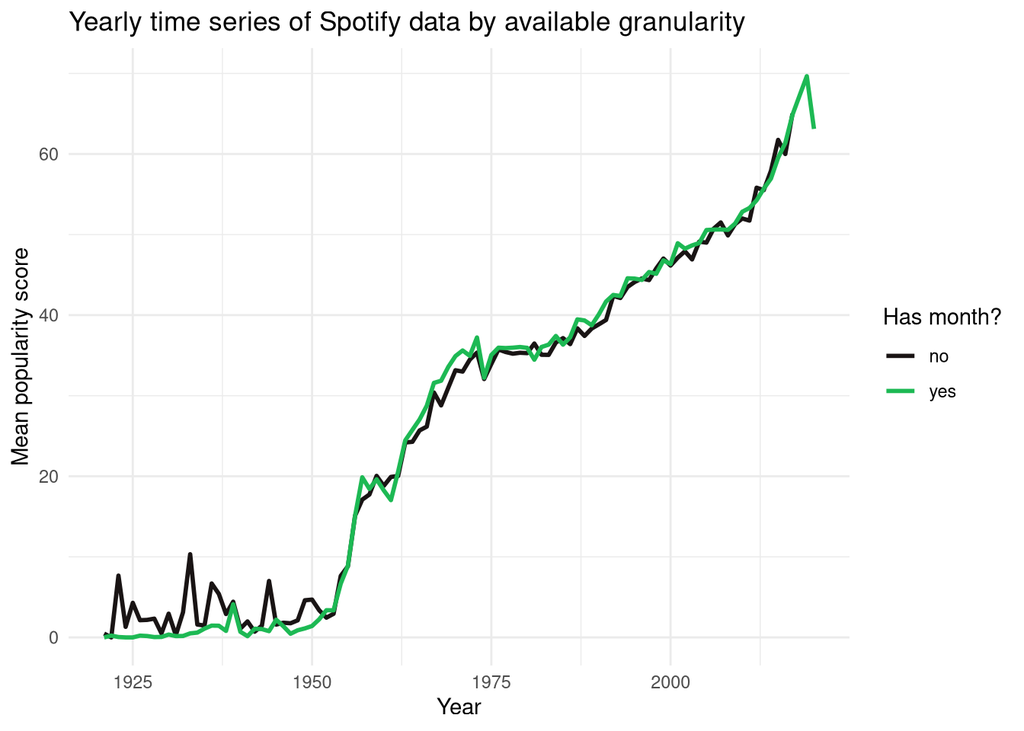

### EDA: Trends over time

In order to get a general sense of the trends in this data, we plotted the mean yearly values of each of the song feature variables.

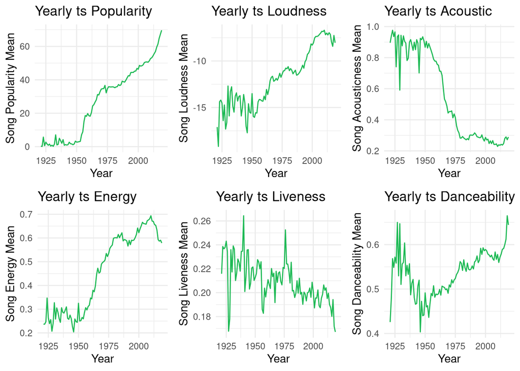

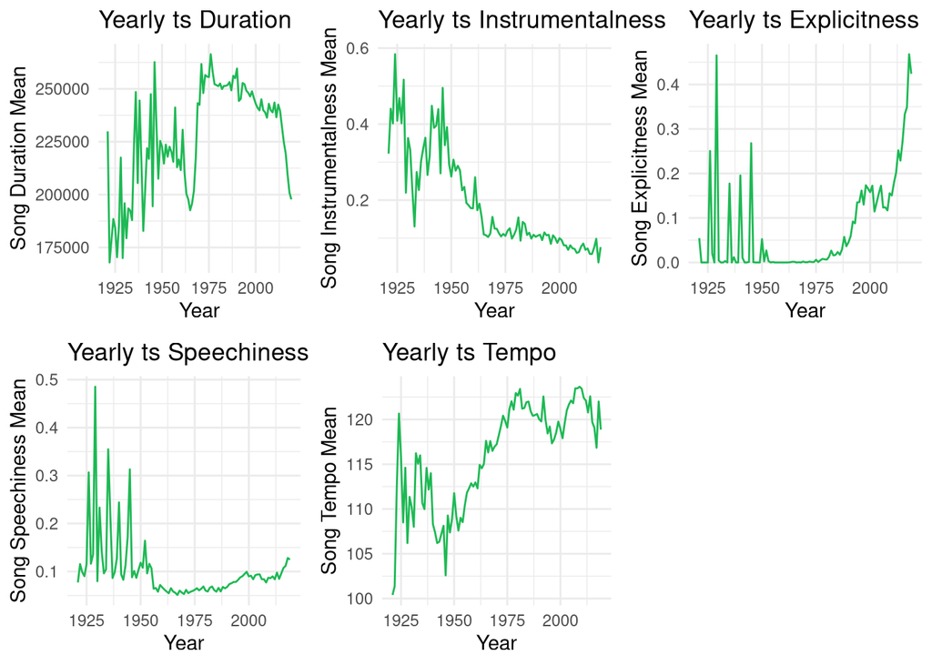

Of note, mean song popularity increased steeply over time. This probably has to do with the rise of the internet and free music streaming, which happened during the last couple of decades. However, mean song popularity decreased sharply in the last couple of years– perhaps because not as many people have had the chance to listen to certain songs yet. Mean loudness and energy have generally increased over time, while mean song acousticness has dropped. Mean song liveness and instrumetalness had moderate downward trends. Mean song duration rose over time but has dropped again in the last couple of decades. Song danceability fell from the 1920s to the 1950s but has been on an upward trajectory ever since.

Now, we plotted the plot the mean monthly values of each of the song feature variables to examine these trends at a more granular level.

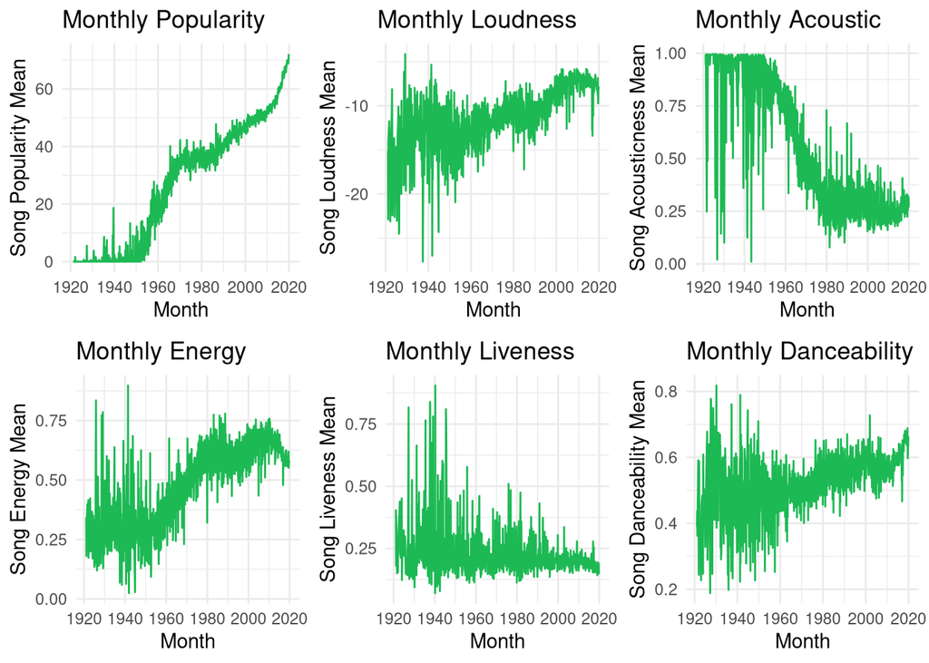

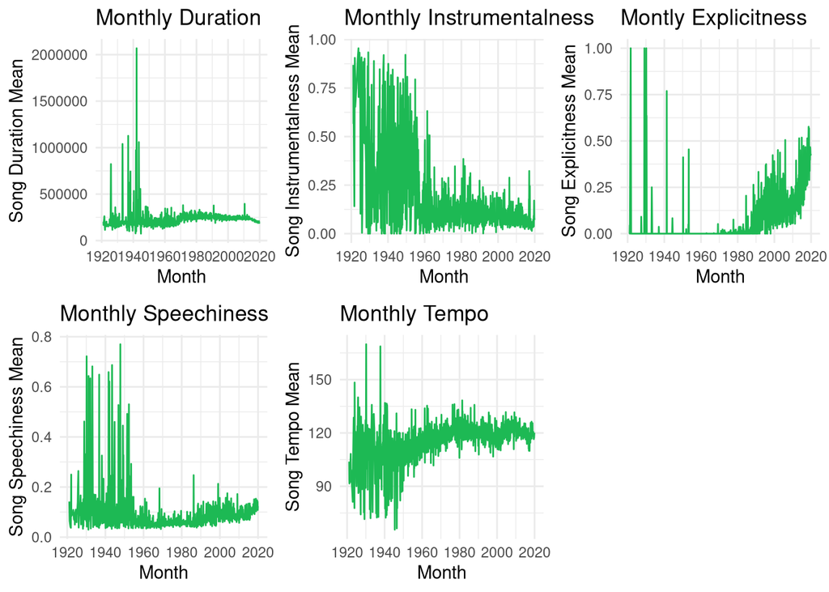

After plotting at a monthly timescale, we can see more nuance in these trends. For instance, the downward trend in liveness that we observed in the yearly time series for liveness appears to be at least partially a result of a couple of months early in the century with particularly high mean liveness that biased the averages. Similarly, for instrumentalness, there seemed to be much more variance in mean monthly values early in the century that created the illusion of a crisper downward trend. Because these monthly time series apear to give us far more information than yearly time series, at this point we chose to create a model that explains monthly mean popularity based on monthly mean predictor values rather than using a yearly temporal granularity. Additionally, the ability to predict monthly mean popularity would likely be more useful for a company than yearly in terms of making timely and specific business decisions.

### Bivariate EDA: Relationships between popularity and song features

To continue our EDA and check which of these covariates might have a relationship with our outocme variable, song popularity, we plotted each variable against the response at monthly granularity. We also fit a rudimentary linear model (black) and loess curve (green) to each.

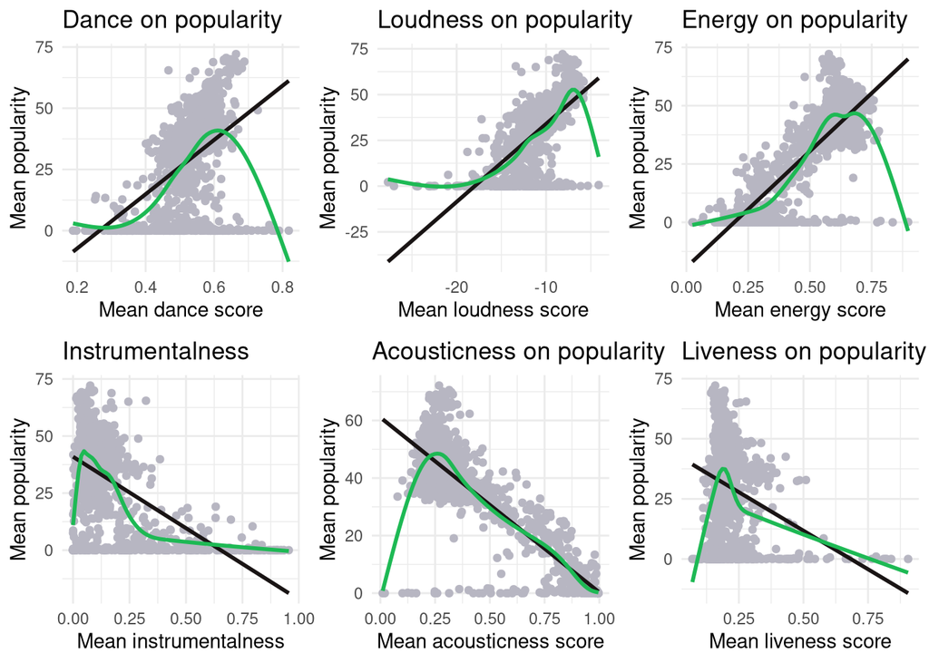

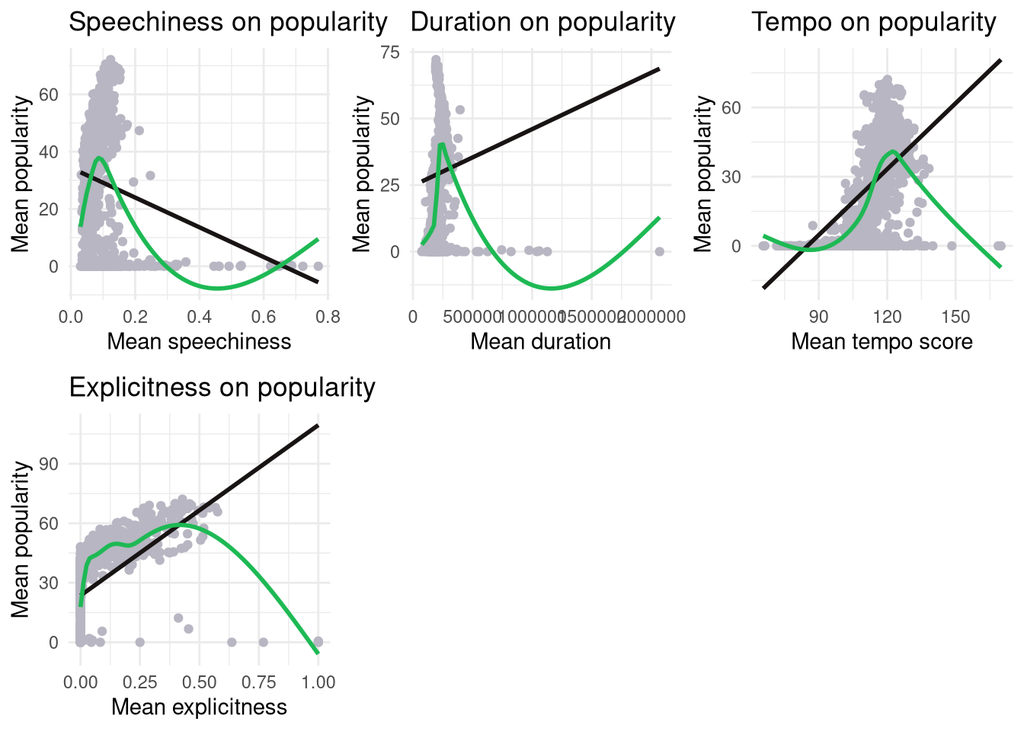

The bivariate EDA (grouped rowwise by behavior), revealed some trends between the predictor and mean monthly song popularity. Danceability, Loudness, and Energy all had relatively strong positive trends with mean song popularity. Instrumentalness, Acousticness, and Liveness all had negative trends with song popularity (higher values of the predictor giving lower song popularity, and vice versa). Speechiness, Duration, and Tempo all had values gathered in one area with various popularity levels, and explicitness had a moderate positve trend with mean song popularity. The loess curve reveals some strange behavior at the very high or very low values of all eight, likely due to the fact that these more extreme popularity values are uncommon.

### Checking cross correlation

For the final step of our EDA, we checked the cross correlation function and correlation coefficients at lags 0-11 for all predictors. For most of the variables, the highest pacf spike was at 0, and calculating the correlations at each lag confirmed that adding a lag would likely not improve the model. Only the tempo variable showed a higher correlation with the addition of lag (lag by 10 months).

| lag | Correlation |
| --- | --- |
| lag 0 | 0.4962417 |
| lag 1 | 0.4988599 |
| lag 2 | 0.4944009 |
| lag 3 | 0.4949888 |
| lag 4 | 0.5003769 |
| lag 5 | 0.5007701 |
| lag 6 | 0.4928117 |
| lag 7 | 0.4979896 |
| lag 8 | 0.4952856 |
| lag 9 | 0.4983904 |
| lag 10 | 0.5009409 |
| lag 11 | 0.4933627 |

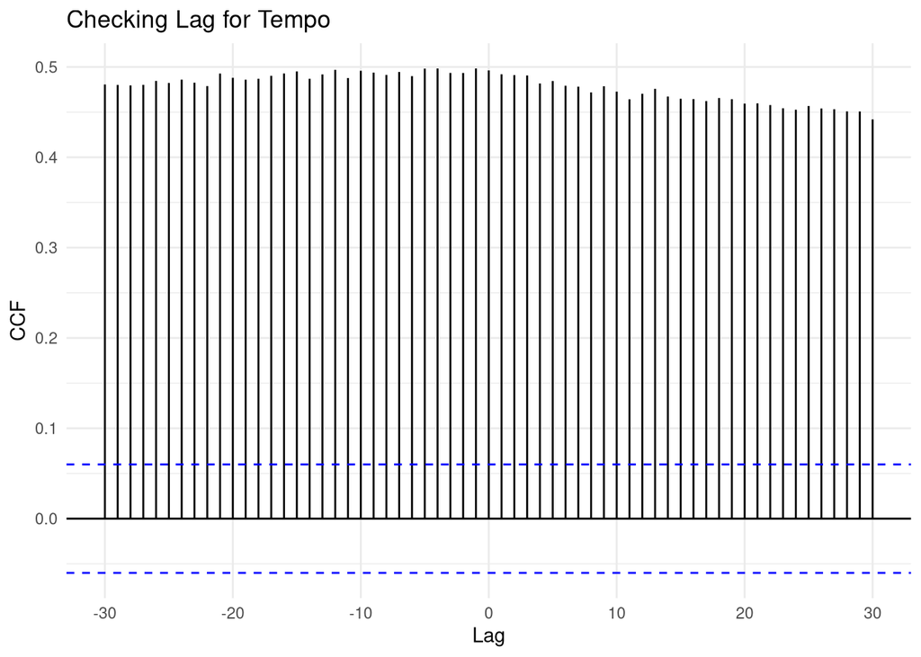

### Fitting preliminary ARIMA model to Popularity scores

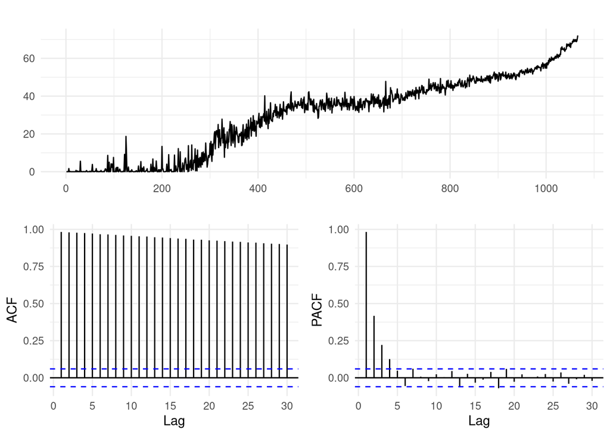

```r
# covert dataframe to time series
spotify_ts <- xts(spotify_mean_monthly$popularity_month_mean, spotify_mean_monthly$month)
spotify_ts <- as.ts(spotify_ts)

# forecast ARIMA
step1 <- forecast::ggtsdisplay(spotify_ts, points = FALSE, theme = theme_minimal())
```

Based on the time series visualization, we will begin by applying first-order differencing with an $ARIMA(0,1,0)$ model. We will also store the root mean squared error value to track our progress while iterating through ARIMA models.

[figure not shown]

```r
# first-order differencing
step2 <- forecast::Arima(
  spotify_ts, order = c(0, 1, 0)
)
forecast::ggtsdisplay(step2$residuals, points = FALSE, lag.max = 36)
```

```r
# store rmse value
step2_rmse <- yardstick::rmse_vec(
  spotify_ts %>% unclass(),
  step2$fitted %>% unclass()
)
```

[figure not shown]

```r
# first order differencing
# MA(2)
step3 <- forecast::Arima(
  spotify_ts, order = c(0, 1, 2)
)
forecast::ggtsdisplay(step3$residuals, points = FALSE, lag.max = 36)
```

```r
# store rmse value
step3_rmse <- yardstick::rmse_vec(
  spotify_ts %>% unclass(),
  step3$fitted %>% unclass()
 )
```

```r
# auto arima on time series
forecast::auto.arima(spotify_ts)
```

```
Series: spotify_ts
ARIMA(0,1,2) with drift

Coefficients:
          ma1     ma2   drift
      -0.8890  0.0515  0.0659
s.e.   0.0315  0.0315  0.0130

sigma^2 = 6.753:  log likelihood = -2527.33
AIC=5062.67   AICc=5062.7   BIC=5082.55
```

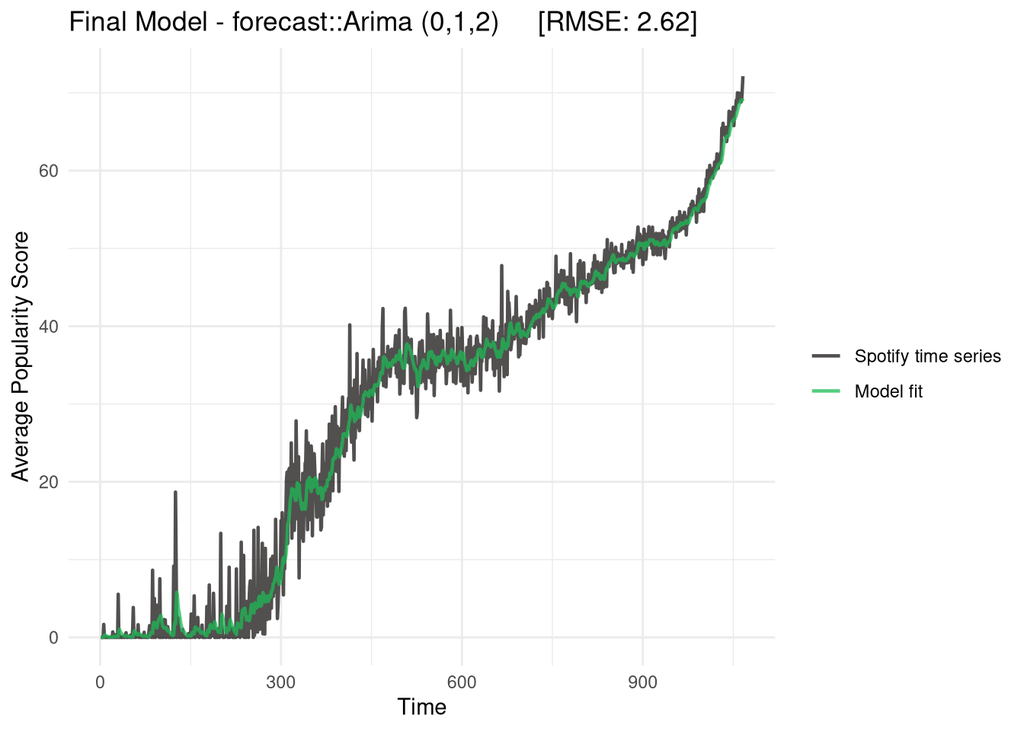

```r
# model fit
model = "Final Model - forecast::Arima (0,1,2) "
rmse = (spotify_ts-step3$fitted)^2 %>% mean() %>% sqrt() %>% round(3) %>% paste0("   [RMSE: ", . ,"]")

step3 %>%
  {tibble(
    spotify_ts = spotify_ts %>% unclass(),
    model = .$fitted %>% unclass(),
    time  = time(.$fitted) %>% unclass()
  )} %>%
  tidyr::gather(var, popularity_year_mean, -time) %>%
  mutate(var = forcats::as_factor(var)) %>%
  ggplot(aes(x=time, y=popularity_year_mean, color=var)) +
  geom_line(alpha=0.75, size=0.8) +
  scale_color_manual(values = c("#191414", "#1DB954"), labels = c("Spotify time series", "Model fit"))+
    labs(title = paste(model, rmse), x = "Time", y = "Average Popularity Score",
         color = "")
```

After applying first order differencing and an MA(2) component, the model fit appears to be finished! The ACF and PACF do not appear to have a pattern after the final step, and the final model against the given data looks sufficient as well. The model for this data required the following parameters: $ARIMA(0,1,2)$, and the final root mean squared error is 2.62.

## Model fitting

Our goal in creating this model is to predict monthly mean song popularity based on monthly mean song features. From our EDA, we can see that danceability, energy, explicitness, instrumentalness, loudness, and tempo had plausibly linear associations with monthly mean song popularity. We will start by fitting a multiple linear regression model with mean monthly popularity as the outcome, the features identified in EDA as predictors, and no temporal component.

```r
# fit model
model1 <- lm(popularity_month_mean ~ danceability_month_mean + energy_month_mean + explicit_month_mean +
               instrumentalness_month_mean + loudness_month_mean + tempo_month_mean, data = spotify_mean_monthly)

# output model
summary(model1)
```

```
Call:
lm(formula = popularity_month_mean ~ danceability_month_mean +
    energy_month_mean + explicit_month_mean + instrumentalness_month_mean +
    loudness_month_mean + tempo_month_mean, data = spotify_mean_monthly)

Residuals:
    Min      1Q  Median      3Q     Max
-88.192  -4.858   0.811   5.789  24.988

Coefficients:
                             Estimate Std. Error t value Pr(>|t|)
(Intercept)                 -24.92776    4.95018  -5.036 5.59e-07 ***
danceability_month_mean       5.66734    4.88026   1.161 0.245791
energy_month_mean            78.90610    3.54047  22.287  < 2e-16 ***
explicit_month_mean          38.47577    3.03301  12.686  < 2e-16 ***
instrumentalness_month_mean -24.56021    1.98068 -12.400  < 2e-16 ***
loudness_month_mean          -0.62190    0.17437  -3.567 0.000378 ***
tempo_month_mean              0.06526    0.03887   1.679 0.093484 .
---
Signif. codes:  0 '***' 0.001 '**' 0.01 '*' 0.05 '.' 0.1 ' ' 1

Residual standard error: 10.34 on 1059 degrees of freedom
Multiple R-squared:  0.7456,    Adjusted R-squared:  0.7442
F-statistic: 517.3 on 6 and 1059 DF,  p-value: < 2.2e-16
```

```r
# store RMSE and AIC
model1_rmse <- yardstick::rmse_vec(
  spotify_mean_monthly$popularity_month_mean,
  model1$fitted
 )
model1_aic <- AIC(model1)
```

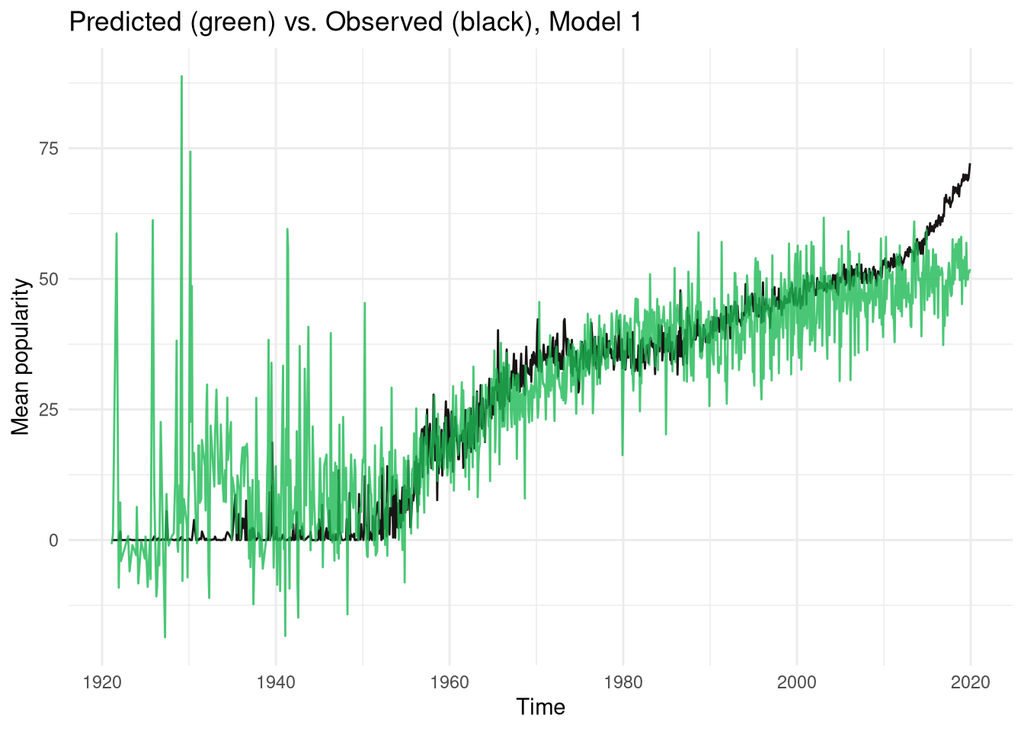

The model performed decently, with an root mean squared error or 10.309 and an AIC of 8015.144. We want to include some temporal component, so we will move forward by adding a temporal component to our existing model with a cross correlation function lag term on the tempo predictor.

```r
# fit model
model2 = lm(popularity_month_mean ~ danceability_month_mean + energy_month_mean + explicit_month_mean +
              instrumentalness_month_mean + loudness_month_mean + tempo_month_mean +
              lag(tempo_month_mean, 10),
            data = spotify_mean_monthly)

# output model
summary(model2)
```

```
Call:
lm(formula = popularity_month_mean ~ danceability_month_mean +
    energy_month_mean + explicit_month_mean + instrumentalness_month_mean +
    loudness_month_mean + tempo_month_mean + lag(tempo_month_mean,
    10), data = spotify_mean_monthly)

Residuals:
    Min      1Q  Median      3Q     Max
-81.740  -4.630   0.888   5.828  22.769

Coefficients:
                             Estimate Std. Error t value Pr(>|t|)
(Intercept)                 -54.08750    5.57833  -9.696  < 2e-16 ***
danceability_month_mean       4.93714    4.66043   1.059  0.28967
energy_month_mean            66.87425    3.56841  18.741  < 2e-16 ***
explicit_month_mean          44.24741    2.97637  14.866  < 2e-16 ***
instrumentalness_month_mean -22.81283    1.93954 -11.762  < 2e-16 ***
loudness_month_mean          -0.48275    0.17034  -2.834  0.00468 **
tempo_month_mean              0.05469    0.03711   1.474  0.14079
lag(tempo_month_mean, 10)     0.32335    0.03186  10.149  < 2e-16 ***
---
Signif. codes:  0 '***' 0.001 '**' 0.01 '*' 0.05 '.' 0.1 ' ' 1

Residual standard error: 9.75 on 1048 degrees of freedom
  (10 observations deleted due to missingness)
Multiple R-squared:  0.7718,    Adjusted R-squared:  0.7702
F-statistic: 506.2 on 7 and 1048 DF,  p-value: < 2.2e-16
```

```r
# store RMSE and AIC
model2_rmse <- model2 %>%
  broom::augment(newdata = spotify_mean_monthly) %>%
  mutate(rmse = yardstick::rmse_vec(popularity_month_mean, .fitted)) %>%
  select(rmse) %>%
  first() %>%
  pull()

model2_aic <- AIC(model2)
```

The new model performed better, with an root mean squared error or 9.713 and an AIC of 7816.361. The temporal component improved the model, so we will move forward by visualizing the residuals and considering a cross correlation function lag term on the response.

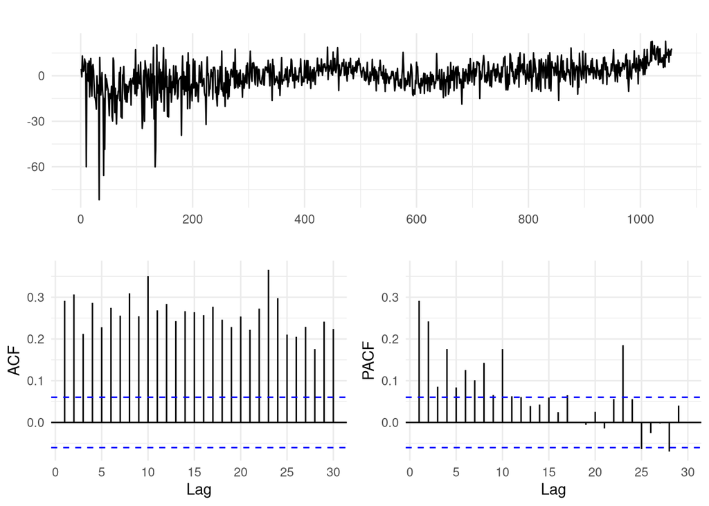

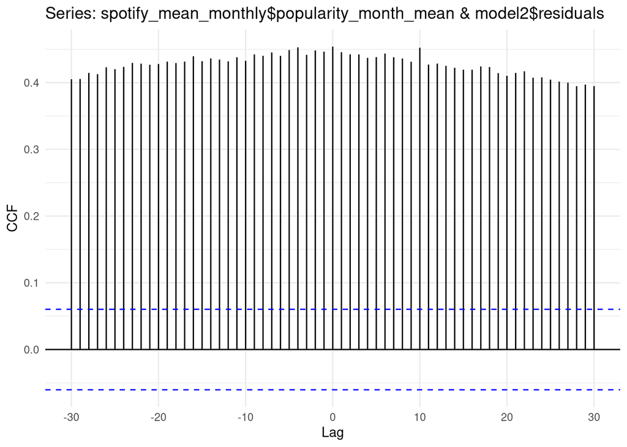

From the residuals of model 2, we can see that there is likely some unaccounted for temporal autocorrelation. In this plot of the CCF of the response variable vs the residuals, we can see a spike at 10, which suggests the use of a lag(10) on the response variable as one of the predictors. For our third model attempt, we will add this predictor to model 2.

```r
# fit model
model3 = lm(popularity_month_mean ~ danceability_month_mean + energy_month_mean + explicit_month_mean +
              instrumentalness_month_mean + loudness_month_mean + tempo_month_mean +
              lag(tempo_month_mean, 10) + lag(popularity_month_mean, 10),
            data = spotify_mean_monthly)

# output model
summary(model3)
```

```
Call:
lm(formula = popularity_month_mean ~ danceability_month_mean +
    energy_month_mean + explicit_month_mean + instrumentalness_month_mean +
    loudness_month_mean + tempo_month_mean + lag(tempo_month_mean,
    10) + lag(popularity_month_mean, 10), data = spotify_mean_monthly)

Residuals:
     Min       1Q   Median       3Q      Max
-16.3356  -1.8929  -0.1428   1.7722  18.1351

Coefficients:
                               Estimate Std. Error t value Pr(>|t|)
(Intercept)                    -0.72306    2.10328  -0.344   0.7311
danceability_month_mean        -0.33879    1.67639  -0.202   0.8399
energy_month_mean               2.49666    1.49398   1.671   0.0950 .
explicit_month_mean             4.90253    1.16780   4.198 2.92e-05 ***
instrumentalness_month_mean    -3.61600    0.73364  -4.929 9.61e-07 ***
loudness_month_mean             0.07786    0.06159   1.264   0.2064
tempo_month_mean                0.00259    0.01335   0.194   0.8463
lag(tempo_month_mean, 10)       0.02911    0.01197   2.430   0.0152 *
lag(popularity_month_mean, 10)  0.92436    0.01100  84.047  < 2e-16 ***
---
Signif. codes:  0 '***' 0.001 '**' 0.01 '*' 0.05 '.' 0.1 ' ' 1

Residual standard error: 3.505 on 1047 degrees of freedom
  (10 observations deleted due to missingness)
Multiple R-squared:  0.9705,    Adjusted R-squared:  0.9703
F-statistic:  4311 on 8 and 1047 DF,  p-value: < 2.2e-16
```

```r
# store RMSE and AIC
model3_rmse <- model3 %>%
  broom::augment(newdata = spotify_mean_monthly) %>%
  mutate(rmse = yardstick::rmse_vec(popularity_month_mean, .fitted)) %>%
  select(rmse) %>%
  first() %>%
  pull()

model3_aic <- AIC(model3)
```

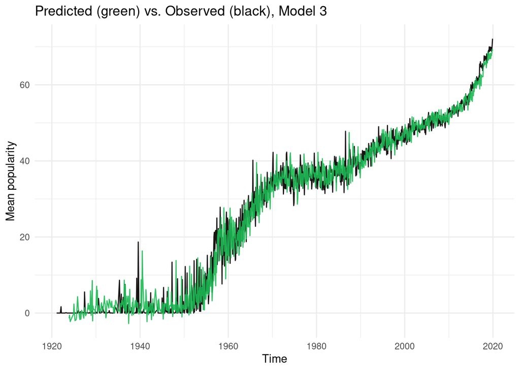

The third model performed even better than the prior two, with an root mean squared error or 3.49 and an AIC of 5656.424. This technique is one way to account for temporal trends in our model, but now we will try a different technique, the use of standard regression as in model 1 but with ARIMA errors.

```r
# Create matrix of predictors
xreg <- cbind(energy_month_mean=spotify_mean_monthly$energy_month_mean,
              explicit_month_mean=spotify_mean_monthly$explicit_month_mean,
              danceability_month_mean=spotify_mean_monthly$danceability_month_mean,
              instrumentalness_month_mean=spotify_mean_monthly$instrumentalness_month_mean,
              loudness_month_mean=spotify_mean_monthly$loudness_month_mean,
              tempo_month_mean=spotify_mean_monthly$tempo_month_mean
              )

# Remove intercept and isolate response variable
xreg <- xreg[,-1]
popularity <- ts(spotify_mean_monthly$popularity_month_mean)

# fit model
model4 <- auto.arima(popularity, xreg=xreg)

# output model
summary(model4)
```

```
Series: popularity
Regression with ARIMA(0,1,2) errors

Coefficients:
          ma1     ma2   drift  explicit_month_mean  danceability_month_mean
      -0.8911  0.0523  0.0646               0.6546                   0.2525
s.e.   0.0314  0.0313  0.0128               0.9501                   1.2202
      instrumentalness_month_mean  loudness_month_mean  tempo_month_mean
                          -1.3288               0.0415           -0.0035
s.e.                       0.5643               0.0362            0.0094

sigma^2 = 6.721:  log likelihood = -2522.29
AIC=5062.58   AICc=5062.75   BIC=5107.32

Training set error measures:
                       ME     RMSE      MAE MPE MAPE      MASE         ACF1
Training set -0.001093683 2.581433 1.819034 NaN  Inf 0.7843184 0.0006724013
```

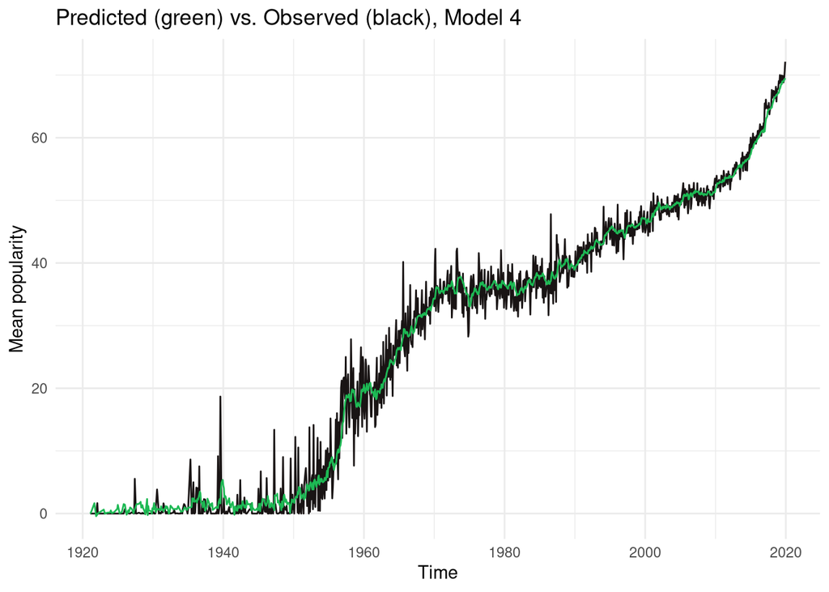

```r
# store AIC
model4_aic <- AIC(model4)

# visualize predicted versus actual
spotify_mean_monthly %>%
  mutate(fitted = model4$fitted) %>%
  ggplot(aes(y = popularity_month_mean, x = month)) +
  geom_line(color = "#191414") +
  geom_line(aes(y = fitted), color = "#1DB954") +
  labs(title = "Predicted (green) vs. Observed (black), Model 4",
       x = "Time", y = "Mean popularity")
```

Interestingly, auto ARIMA produced the same ARIMA model as the ARIMA model we fit to the mean monthly popularity time series in EDA. This model had the best AIC value of all four models, yielding an AIC of 5062.581.

## Discussion

In this project, we fit a model to the mean popularity of songs released every month from 1920 to 2020 using multiple linear regression with ARIMA errors. We started by doing univariate exploratory data analysis, at which point we decided to construct our model at a monthly temporal granularity. Then, we did bivariate analysis to investigate the relationship between each potential predictor variable and mean monthly popularity. We used this analysis to select predictor variables for our model. Our initial model was a simple multiple linear regression model with mean popularity as the dependent variable and each of the mean monthly predictor variables as covariates. After plotting the predicted values from this model against the actual data, it was clear that the combination of covariates we had chosen did have value in predicting the mean monthly popularity, as expected based on the relationships we observed during bivariate analysis. However, there was clearly still a lot of noise that was unaccounted for, which we suspected was due to temporal trends in the data. We decided to try two different approaches to accounting for the spatial component of this model. First, we used cross-correlation functions to check whether lagging any of the predictors would be useful; we ended up lagging one of the variables by 10 month and then based on the residuals of that model we included a 10-month lag on the response variable as one of the predictors. Both of these steps lowered the AIC, which we used as a model comparison metric. For our second approach, we used the same original multiple linear regression model but then fit an ARIMA model to the leftover temporal autocorrelation. Interestingly, using the automatic ARIMA function generated the same ARIMA parameters (0,1,2) as the manually fitted ARIMA model we fitted to the mean monthly popularity time series as part of exploratory data analysis. This model produced the lowest AIC value of all of the models fit up to that point, leading us to believe that a multiple linear regression with ARIMA errors is better suited to this data than using lagged predictors as covariates in a traditional regression model.

From healthcare data to company analytics, real-world data often includes temporal components. Models of indices like the Spotify popularity index are essential for a company’s ability to predict trends over time and to understand what factors impact customer engagement in relation to time. We have found that a multiple linear regression model with ARIMA errors is best suited to modeling mean monthly song popularity based on song release dates and other features data. Future investigations of temporal trends in Spotify data could include split modeling to gain a better understanding of how predictors have differentially affected popularity depending on the time period of release date and dividing up the three facets of the popularity index (listen total, frequency and recency) to see how predictors affect these outcomes differently. A key limitation of this project is that while the acoustic features of songs likely trend towards certain values based on what is popular in society at a given time, they fail to capture elements like artist popularity and media/social media attention that are inherently essential considerations in modeling song popularity. Spotify also has a measure of artist popularity, and future modeling projects using this data should consider linking that metric to this data as a proxy measure for the various components of the public attention directed toward a song that are likely to be extremely predictive of its popularity .

### Appendix/ Extra Analysis:

As a supplement to our analysis of mean monthly song popularity, we decided to do an analysis of the predictors of individual song popularity, given the potential usefulness of this kind of model for music-industry professionals. We used Python instead of R for this supplementary analysis. After conducting a more detailed exploratory data analysis that included more data visualization, outlier detection (detection of white noise and other non-song tracks) and an investigation of the interaction between time period and each predictor, we fit a simplified regression model using just song metrics, a regression model with interactions that account for the temporally varying nature of the data (song metrics interacted with the decade they are from), and a neural network and compared the three models.

The notebook and modeling PDF have been excluded from this report due to their length. However, they are linked below in order to show the modeling code, extra data visualization of initial data and modeling, and other interesting findings:

[Link to popularity modeling notebook here](https://github.com/sta344-fa22/project_fapka/blob/main/Popularity%20Modeling.pdf)

[Link to popularity modeling PDF (code not suppressed due to Co-Lab) here](https://github.com/sta344-fa22/project_fapka/blob/main/Popularity_Modeling.ipynb)

Below is the regression model using just song metrics.

Simple model RMSE score on unseen testing data: 253.76717755170372 Simple model R^2 score on unseen testing data: 0.4594513660578803

Model coefficients: acousticness: -8.70890032844128 danceability: 4.725511699386118 energy: 3.0230875281940155 instrumentalness: -2.1648771721870097 liveness: -1.3400239544709236 loudness: 1.8206445604067238 speechiness: -3.870777766773358 tempo: 0.7732670288440187 valence: -5.992685131340313

Below is a plot of X being the predicted popularity by the model and Y being the true popularity.

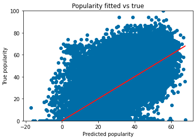

```r
knitr::include_graphics('Simple Fit.png')
```

We then created a model using a regression of the 30 most important features found by a recursive feature elimination of interactions between every decade and each song metric. Interactions were used as the relationship a song metric has with popularity appeared to change throughout time, based on the trend of the era, which was demonstrated in the data visualization in the report. Additionally, music itself has become more popular in time, or rather, more recent music will have more streams on Spotify by nature of its constituency.

Interaction Model RMSE score on unseen testing data: 110.30700501688433 Interaction Model R^2 score on unseen testing data: 0.7650354098138841

Key interactions from RFE and their model coefficients are here: loudness: 1.955019764713686 liveness decade_1930s: -0.7365795509716904 liveness decade_1940s: -0.8330378819254411 liveness decade_1950s: -1.1160949945848566 loudness decade_1920s: 1.653104295372457 loudness decade_1930s: 1.7785506336976447 loudness decade_1940s: 2.468405932240749 loudness decade_1950s: 2.4906150362532293 loudness decade_1960s: 0.7324174939096625 loudness decade_1970s: -0.9017162603079788 loudness decade_1980s: -1.5031282035185953 loudness decade_1990s: -1.2358471318714634 loudness decade_2000s: -1.518849246918148 loudness decade_2010s: -2.76271164629178 loudness decade_2020s: -0.8417724430242697 tempo decade_1920s: -1.9963257698227217 tempo decade_1930s: -2.6059709982508203 tempo decade_1940s: -3.3781652112909732 tempo decade_1950s: -2.683114942238923 tempo decade_1960s: -1.3043675883530166 tempo decade_1990s: 2.2889791360769687 tempo decade_2000s: 2.7200342426489135 tempo decade_2010s: 4.527613081101399 tempo decade_2020s: 2.2093543680604357 valence decade_1920s: -1.1716105895566549 valence decade_1930s: -1.539505935712829 valence decade_1940s: -2.083877729848254 valence decade_1950s: -1.0206622976672919 valence decade_2000s: 1.0991800478138372 valence decade_2010s: 1.5955956244671379

Below is a plot of X being the predicted popularity by the model and Y being the true popularity.

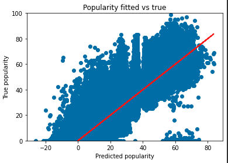

```r
knitr::include_graphics('Interaction Fit.png')
```

Finally, we applied a deep learning approach using the song metrics and temporal information to see how the predictive accuracy would change.

Neural Networks create an uninterpretable, but perhaps better predictive model for the data. There is a lot of data, such that neural networks may train better in this setting. Furthermore, neural networks can learn complex relationships, interactions, and dependencies between variables, helping reduce the need for manual feature engineering and feature selection.

While LSTMs are often used do the sequential nature of Recurrent Neural Networks and the LSTMs ability to use memory and forget gates to keep and drop important information, the data we have is time series but not sequential, as the observations are generally independent of each other, but rather the observations and their co-variates/popularity scorres are just not independent from time/era.

Thus, we use an Artificial Neural Network with a ReLU final activation function. In doing so, we bring a longer training and inference time, and the potential of overfitting. Additionally, we do not have the time to truly tune the neural network in terms of its architecture, dropout rate, regularization, optimizer, etc. Meanwhile, a Linear Regression can easily be tuned (for parameters like L1/L2 penalties and such) with a Grid Search in minutes. Finally, with the neural network, we lose interpretability in favor of predictive accuracy.

NN Model RMSE score on unseen testing data: 84.26029562585006 NN Model R^2 score on unseen testing data: 0.8205174201977617

Below is a plot of X being the predicted popularity by the model and Y being the true popularity.

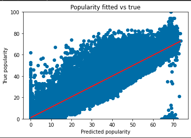

```r
knitr::include_graphics('NN Fit.png')
```

Here, we explore Neural Networks to create an uninterpretable, but perhaps better predictive model for the data. There is a lot of data, such that neural networks may train better in this setting. Furthermore, neural networks can learn complex relationships, interactions, and dependencies between variables, helping reduce the need for manual feature engineering and feature selection.

While LSTMs are often used do the sequential nature of Recurrent Neural Networks and the LSTMs ability to use memory and forget gates to keep and drop important information, the data we have is time series but not sequential, as the observations are generally independent of each other, but rather the observations and their co-variates/popularity scorres are just not independent from time/era.

Thus, we use an Artificial Neural Network with a ReLU final activation function. In doing so, we bring a longer training and inference time, and the potential of overfitting. Additionally, we do not have the time to truly tune the neural network in terms of its architecture, dropout rate, regularization, optimizer, etc. Meanwhile, a Linear Regression can easily be tuned (for parameters like L1/L2 penalties and such) with a Grid Search in minutes. Finally, with the neural network, we lose interpretability in favor of predictive accuracy.

#### Key Takeaways from Appendix: Modeling

The Neural Network performs better than the Linear Regression, with its R squared of 0.82 and RMSE of 84.2. The RMSE appears to be high in both the linear regression and neural network due to some especially high residuals that come from the recent 2020s data. This network, while not fully tuned, is meant to represent an upper bound benchmark for how well we can model popularity with song metrics.

There is a clear performance boost from adding temporal information, which makes sense as many variables even changed sign in terms of their coefficients from earlier decades to later decades in the model, suggesting a shift in its impact on popularity. Additionally, music itself gained in popularity score, which also changes its relationships with other variables. In the simplified regression approach, it seemed as though different relationships between the target and a metric over different decades led to an “averaging” effect over coefficients not allowing any of the relationships to be learned. Thus, this could be benefited by including interaction effects by decade for more nuanced relationships between metrics and popularity scores.

The Neural Network’s performing better than the interaction regression shows there is still more left to be desired in the interpretable regression. There may be complex non-linear relationships the network finds, for exmaple, transforms or potentially even more structured change points in the relationships between song metrics and popularity. Further feature engineering and selection should ideally be performed to increase the interpretable model’s performance relative to the neural network to eke out as much information as possible on the relationships between metrics and song popularity. More specifically, future work on this project would definitely include change point detection and analysis to further boost the interpretable modeling.

Ultimately, due to a time constraint change point detection was not able to be tested for the model. This may have proved beneficial, as the decade splits created a sparser data set with many features to learn. Finding the change points for each variable in their relations with popularity would have created a model that was more precise in terms of its engineered features, and would have allowed it to better learn the ‘eras’ of music.

In the model fitting part of our analysis, we had two goals: 1) Track change in popularity over the months using other variable means through ARIMA (done in earlier section) 2) Use tempora relationships between metrics (found from prior analysis or feature selection with RFE) to predict popularity at the individual scale rather than the monthly scale. This accounts for nuance of the music in decades. Ultimately, the modeling done demonstrates the validity of many of the metric relationships found earlier in the report as a predictor of not merely monthly song popularity, but individual song popularity.

#### Key Takeaways from Appendix: Data Cleaning

In the future, I would filter out extremely recent data as its popularity score is only low due to the recency of it coming out. This data can then be run through the model as a “forecasting set”, in which we predict what these songs future popularity scores will be.

Interestingly, even a neural network can not learn the training data that well (> R squared only in the 0.8 range), which I believe a further reflection of the fact that the metrics + temporal information is not a great proxy for predicting popularity.

Some further data cleaning to remove non-songs could also be helpful. For example, there are non-song outliers, songs too recent for a popularity score, and a strong sampling bias in the data in terms of recent songs generally being of a higher popularity than other decades (proportions of popularity scores- some of this is trend in music, but also some less known tracks are just not being included).

#### Key Takeaways from Appendix: Predictive Nature of Data

It is clear from the scatter plots that the data here has high variance- songs with very similar song metrics can and often will have widely different popularities. This is ultimately because the data itself is not nuanced enough to produce a truly great predictor of a song’s popularity.

In thinking about what goes into a popular song nowadays, while there are absolutely trends in how songs are made, this will not be able to solely tell you the popularity. There is so much music nowadays that most music with any combination of song metrics will not have a high popularity, since it is challenging to break the glass ceiling.

Furthermore, more data is definitely required to truly predict a song’s popularity score. For example, two artists (e.g. Kendrick Lamar and Billy Joel)releasing songs with the same song metrics will lead to wildly different results. There are many factors that go into songs making the charts nowadays, including how famous an artist already is, its use in social media/pop culture leading to it trending, as well as other factors that make people like a given song. Additionally, data about what niche the artist/its fans fall into could be helpful to know how a song and its given metrics falls into a niche. While this would be helpful, it is still really challenging to create a model that will predict any kind of break through from a small artist, given data on fame. However, one can make a model that ranks songs well in terms of their ability to become popular, given a bunch of small artists, which seems like a great use case of this kind of song data.

Ultimately, music is quite hard to quantify, and more data is required to truly determine what will make people like and listen to songs.